# Análise IBNR Estocástico - Carteira Fictícia

# 1 Dados, Pacotes Utilizados e Semente

A semente utilizada foi: 732634202

Com o objetivo de divulgar o relatório, foram utilizados dados fictícios chamados GenIns obtidos do pacote ChainLadder.

```r
library(openxlsx)
library(readxlsb)
library(ChainLadder)
library(MASS)
library(dplyr)
library(knitr)
library(magrittr)
library(kableExtra)
library(htmltools)
library(rmdformats)
```

# 2 Análise Imobiliarios

Primeiramente, analisamos o padrão de desenvolvimento dos sinistros. No gráfico podemos observar que os sinistros possuem diferentes desenvolvimentos de acordo com o período de origem. Por exemplo, os períodos 2, 3 e 4 apresentam os maiores valores acumulados, indicando que sinistros ocorridos nesses períodos têm um desenvolvimento mais significativo ao longo do tempo.

## 2.1 Análise padrões de desenvolvimento e fatores

### 2.1.1 Desenvolvimento dos Sinistros

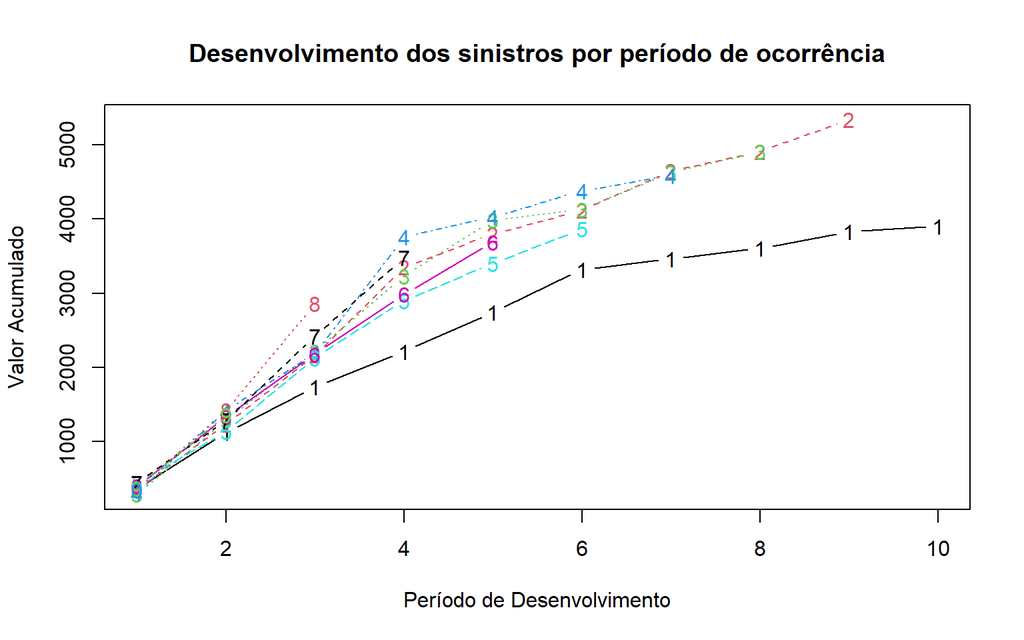

| Lag 0 | Lag 1 | Lag 2 | Lag 3 | Lag 4 | Lag 5 | Lag 6 | Lag 7 | Lag 8 | Lag 9 |
| --- | --- | --- | --- | --- | --- | --- | --- | --- | --- |
| 357.848 | 1.124.788 | 1.735.330 | 2.218.270 | 2.745.596 | 3.319.994 | 3.466.336 | 3.606.286 | 3.833.515 | 3.901.463 |
| 352.118 | 1.236.139 | 2.170.033 | 3.353.322 | 3.799.067 | 4.120.063 | 4.647.867 | 4.914.039 | 5.339.085 | NA |
| 290.507 | 1.292.306 | 2.218.525 | 3.235.179 | 3.985.995 | 4.132.918 | 4.628.910 | 4.909.315 | NA | NA |
| 310.608 | 1.418.858 | 2.195.047 | 3.757.447 | 4.029.929 | 4.381.982 | 4.588.268 | NA | NA | NA |
| 443.160 | 1.136.350 | 2.128.333 | 2.897.821 | 3.402.672 | 3.873.311 | NA | NA | NA | NA |
| 396.132 | 1.333.217 | 2.180.715 | 2.985.752 | 3.691.712 | NA | NA | NA | NA | NA |
| 440.832 | 1.288.463 | 2.419.861 | 3.483.130 | NA | NA | NA | NA | NA | NA |
| 359.480 | 1.421.128 | 2.864.498 | NA | NA | NA | NA | NA | NA | NA |
| 376.686 | 1.363.294 | NA | NA | NA | NA | NA | NA | NA | NA |
| 344.014 | NA | NA | NA | NA | NA | NA | NA | NA | NA |

A Soma da última diagonal é igual a: 34.358.090

### 2.1.2 Fatores de desenvolvimento

Podemos observar o comportamento dos fatores de desenvolvimento ao longo dos períodos e uma tabela com a média ponderada desses fatores.

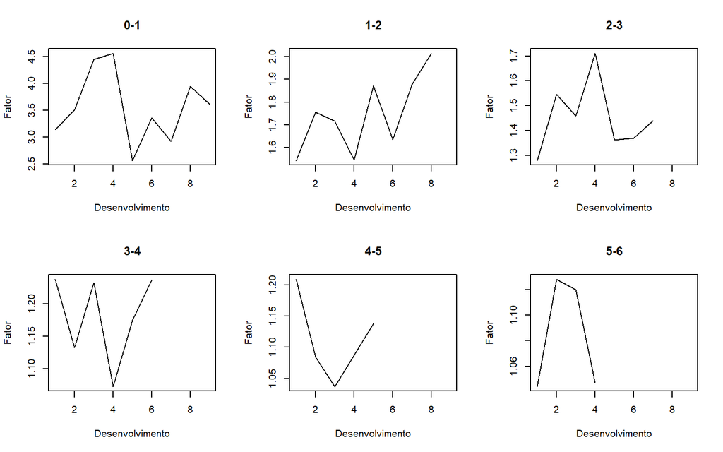

| 0-1 | 1-2 | 2-3 | 3-4 | 4-5 | 5-6 | 6-7 | 7-8 | 8-9 |
| --- | --- | --- | --- | --- | --- | --- | --- | --- |
| 3.4906 | 1.7473 | 1.4574 | 1.1739 | 1.1038 | 1.0863 | 1.0539 | 1.0766 | 1.0177 |

## 2.2 Método Bootstrap

Foi realizado o cálculo do IBNP via método de bootstrap com 10.000 replicações, e obtivemos o seguinte resultado:

### 2.2.1 Histograma Bootstrap

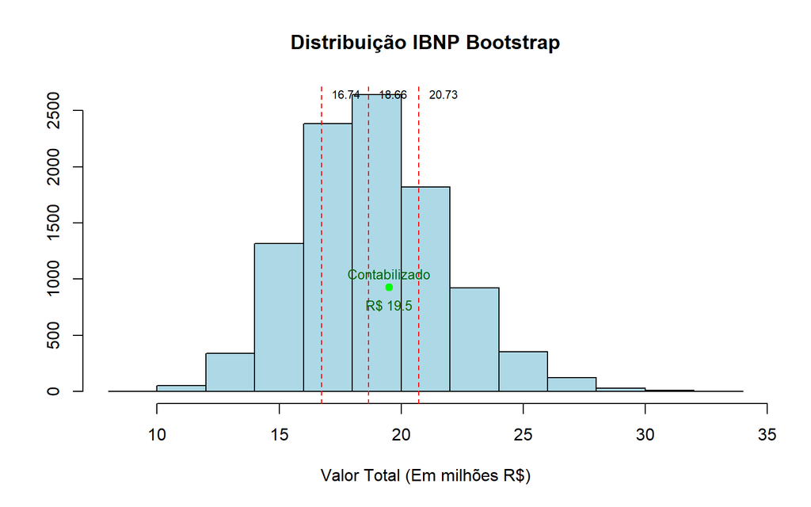

O intervalo de confiança 95% da distribuição é : $IC_{0.95}:$ [13,47, 25,32]

O intervalo de confiança 99% da distribuição é : $IC_{0.99}:$ [11,84, 27,78]

O valor contabilizado **R$19.500.000**, representa o percentil 0.61 da distribuição.

### 2.2.2 Tabela por Período de Ocorrência

| Quantil 50% | Quantil 75% | Quantil 95% |
| --- | --- | --- |
| 0 | 0 | 0 |
| 95.667 | 148.167 | 316.023 |
| 471.526 | 603.863 | 870.003 |
| 712.509 | 869.757 | 1.181.450 |
| 990.243 | 1.181.146 | 1.549.260 |
| 1.425.483 | 1.664.136 | 2.097.342 |
| 2.190.279 | 2.507.815 | 3.066.168 |
| 3.953.567 | 4.455.001 | 5.340.113 |
| 4.301.067 | 4.921.174 | 6.180.441 |
| 4.699.125 | 5.898.306 | 8.248.589 |

### 2.2.3 Ajuste Distribuição

Ajustando uma distribuição aos valores gerados de IBNP:

```
##      meanlog         sdlog
##   16.738733624    0.160026451
##  ( 0.001600265) ( 0.001131558)
```

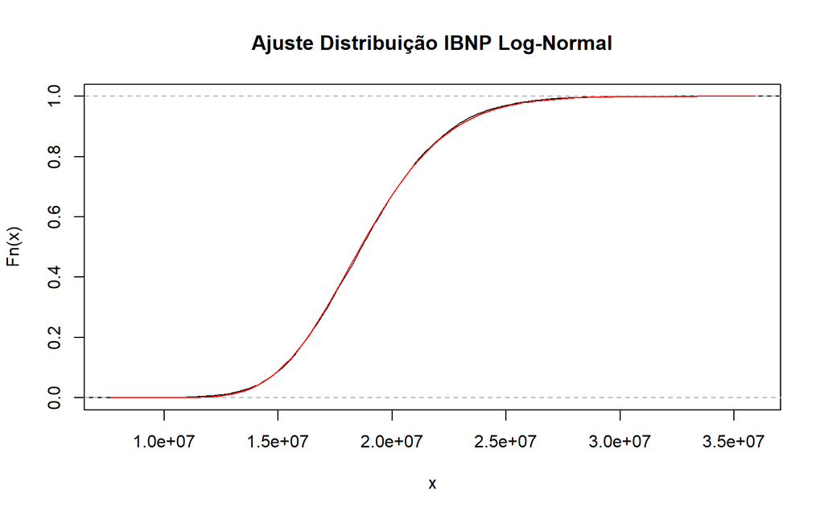

### 2.2.4 Teste de Sensibilidade Bootstrap

|  | 50 Rep | 100 Rep | 1000 Rep | 5000 Rep | 10000 Rep |
| --- | --- | --- | --- | --- | --- |
| 2.5% | 13.766.041 | 13.647.077 | 13.618.752 | 13.635.871 | 13.472.534 |
| 50% | 18.715.850 | 18.549.690 | 18.652.464 | 18.660.478 | 18.658.770 |
| 97.5% | 24.900.468 | 24.668.179 | 24.946.523 | 25.379.409 | 25.316.715 |

## 2.3 Modelo de Regressão de Poisson

Foi realizado um ajuste de um modelo de Regressão de Poisson, a ideia é considerar que $X_{ij}$ têm distribuição de Poisson, dado o período de origem $a_i$, e o período de desenvolvimento $b_j$, como intercepto c.

$$\log E(X_{ij})=\eta_{ij} = c + a_i + b_j$$

### 2.3.1 Predição do Modelo

O valor estimado de IBNP gerado pelo modelo foi de: **R$17.907.759**

### 2.3.2 Tabela Coeficientes Regressão

|  | Estimate | Std. Error | z value | Pr(>&#124;z&#124;) |
| --- | --- | --- | --- | --- |
| (Intercept) | 12.5366 | 0.0006 | 20765.0214 | 0 |
| origin10 | 0.2118 | 0.0018 | 117.0971 | 0 |
| origin2 | 0.2895 | 0.0003 | 1036.3450 | 0 |
| origin3 | 0.2898 | 0.0003 | 970.4361 | 0 |
| origin4 | 0.3331 | 0.0003 | 1049.6758 | 0 |
| origin5 | 0.1967 | 0.0004 | 548.9566 | 0 |
| origin6 | 0.2497 | 0.0004 | 631.9712 | 0 |
| origin7 | 0.3484 | 0.0004 | 776.8377 | 0 |
| origin8 | 0.4554 | 0.0006 | 827.8937 | 0 |
| origin9 | 0.3308 | 0.0008 | 393.7490 | 0 |
| factor(dev)2 | 1.2501 | 0.0006 | 2010.4108 | 0 |
| factor(dev)3 | 1.8071 | 0.0006 | 2990.3967 | 0 |
| factor(dev)4 | 2.1712 | 0.0006 | 3615.6877 | 0 |
| factor(dev)5 | 2.3302 | 0.0006 | 3856.6603 | 0 |
| factor(dev)6 | 2.4279 | 0.0006 | 3977.6243 | 0 |
| factor(dev)7 | 2.5086 | 0.0006 | 4052.5215 | 0 |
| factor(dev)8 | 2.5756 | 0.0006 | 4047.1244 | 0 |
| factor(dev)9 | 2.6467 | 0.0007 | 3954.3367 | 0 |
| factor(dev)10 | 2.6402 | 0.0008 | 3350.8786 | 0 |

### 2.3.3 Diagnóstico do Modelo

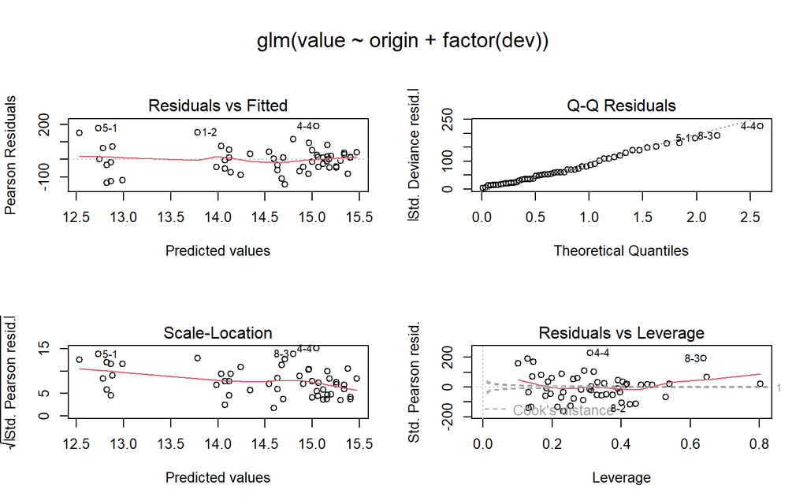

## 2.4 Método de Mack

Foi utilizado o método de Mack para fazer uma nova previsão do IBNR, e os seguintes resultados foram encontrados:

O Valor Total de IBNP estimado foi **R$18.680.856**

### 2.4.1 Tabela por Período de Ocorrência

| IBNR | Erro padrão de Mack |
| --- | --- |
| 0 | 0 |
| 94.634 | 71.835 |
| 469.511 | 119.474 |
| 709.638 | 131.573 |
| 984.889 | 260.530 |
| 1.419.459 | 410.407 |
| 2.177.641 | 557.796 |
| 3.920.301 | 874.882 |
| 4.278.972 | 970.960 |
| 4.625.811 | 1.362.981 |

### 2.4.2 Diagnóstico do Modelo de Mack

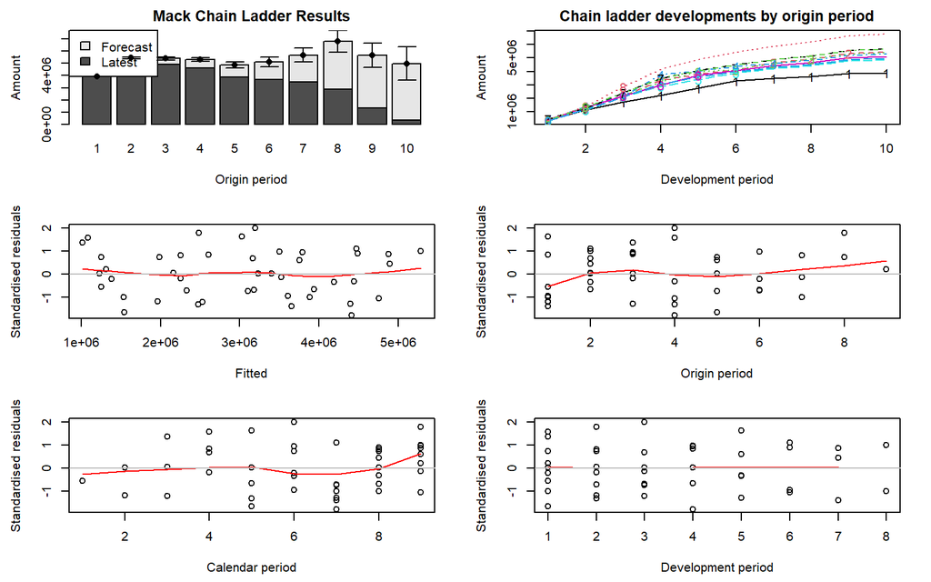